# Stats Exam

K Nel

31 August 2016

# Question 1

*Null Hypothesis:* There is no association between sex (independent), and one’s body temperature and heart rate (both dependent).

*Alternative Hypothesis:* There is an association between sex (independent), and one’s body temperature and heart rate (both dependent).

There are 2 groups of unpaired data (male and female), and the data is numerical and continuous. The mean and median are almost identical for both variables (temp + HR), so I can conclude the data is parametric. Therefore, I will perform a Student’s or unpaired t-test.

*The assumptions for this test are as follows:* The distribution for the data in the population is Gaussian; there is equal variance across groups; the errors are independent; and the data are unmatched.

```
## # A tibble: 130 x 3
##      Sex body_temperature heart_rate
##    <chr>            <dbl>      <int>
## 1   male             35.7         70
## 2   male             35.9         71
## 3   male             36.1         74
## 4   male             36.1         80
## 5   male             36.2         73
## 6   male             36.2         75
## 7   male             36.2         82
## 8   male             36.2         64
## 9   male             36.3         69
## 10  male             36.3         70
## # ... with 120 more rows
```

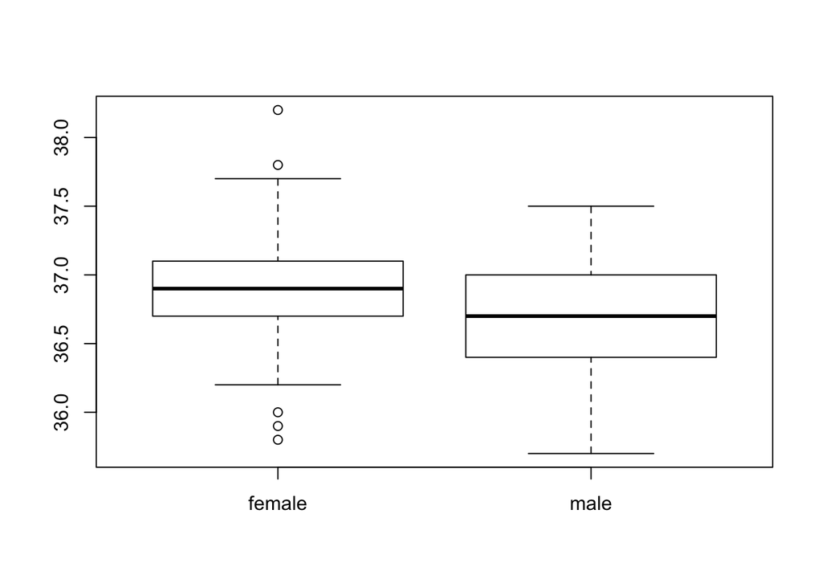

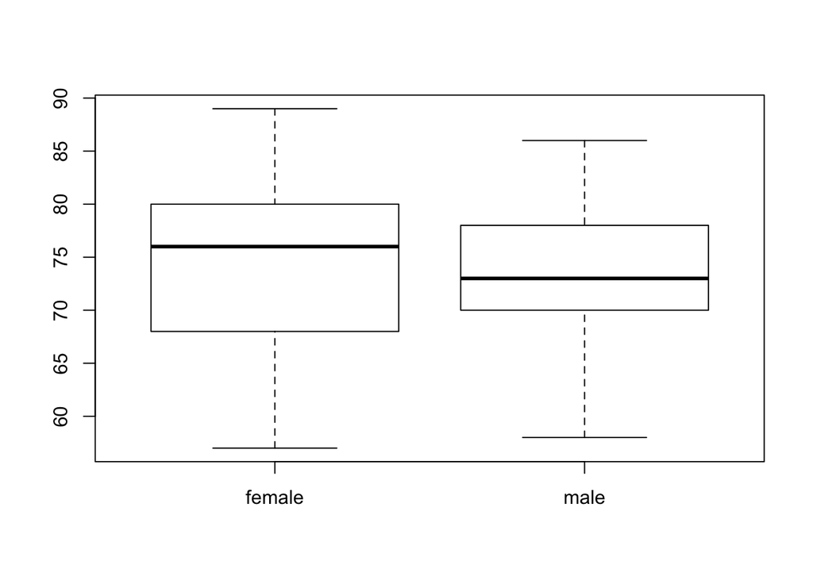

```
##
##  Welch Two Sample t-test
##
## data:  body_temperature by Sex
## t = 2.3204, df = 127.52, p-value = 0.02191
## alternative hypothesis: true difference in means is not equal to 0
## 95 percent confidence interval:
##  0.02400893 0.30214491
## sample estimates:
## mean in group female   mean in group male
##             36.88923             36.72615
```

```
##
##  Welch Two Sample t-test
##
## data:  heart_rate by Sex
## t = 0.63191, df = 116.7, p-value = 0.5287
## alternative hypothesis: true difference in means is not equal to 0
## 95 percent confidence interval:
##  -1.674501  3.243732
## sample estimates:
## mean in group female   mean in group male
##             74.15385             73.36923
```

```
##      Sex            body_temperature   heart_rate
##  Length:130         Min.   :35.70    Min.   :57.00
##  Class :character   1st Qu.:36.60    1st Qu.:69.00
##  Mode  :character   Median :36.80    Median :74.00
##                     Mean   :36.81    Mean   :73.76
##                     3rd Qu.:37.10    3rd Qu.:79.00
##                     Max.   :38.20    Max.   :89.00
```

*Results for the association between gender and body temperature:* t = 2.3204, df = 127.52, p-value = 0.02191 Confidence interval = 95% (0.024 to 0.302)

The difference between the two means is significant because the t-value is greather than that in a lookup table, with degrees of freedom being about 128 and p value = 0.05. Therefore we reject the null hypothesis and accept the alternative hypothesis.

*Results for the association between gender and heart rate:* t = 0.6319, df = 116.7, p-value = 0.5287 Confidence interval = 95% (-1.6745 to 3.2437)

*Interpretation of results:* There is an association between gender and body temperature, however there is no significant association between gender and heart rate.

# Question 2

*Null Hypothesis:* There is no association between handedness and ataxic walking in intoxicated individuals.

*Alternative Hypothesis:* There is an association between handedness and ataxic walking in intoxicated individuals.

There are 2 groups of unpaired data (right and left handedness), and the data is categorical and nominal.

The mean and median are not similar for both variables (“first stumble” and “final position”), so I can conclude the data is non-parametric. Therefore, I will perform a Fishers-Exact. The assumptions for this test are as follows: 1) the sampling was done randomly 2) the observations are independent 3) there is a large sample with adequate expected cell counts for a 2 x 2 table: Expected >= 5 in all cells 4) it assumes the discrete probability of observed frequencies in the table can be approxiamtaed by the continuous chi-squared value

```r
#Read directly from URL
data_q2 <- read.csv('https://dl.dropboxusercontent.com/u/11805474/painblogr/biostats/exam-data-2016/question2.csv')

#Load data into a data frame table
table_q2 <- tbl_df(data_q2)

#Tidy the data
##Add a coloumn for change in direction
mutate_q2 <- mutate(table_q2, 'change' = first_stumble + final_position)

##Select columns being used for simplicity
final_q2 <- select(mutate_q2, handedness, change)

##Add column for presence of ataxia
#ataxia_q2 <- mutate(final_q2, if(change==1){ataxia='present'}, if(change==0 | change=2){ataxia='absent'})

#The above ataxia_variable creation did not work with the mutate function, and so I manually analysed the data and created my own dataset in a text document
#Import text dataset
import_q2 <- read.table('question2ataxia.txt',
                 header = TRUE)

summary(import_q2)
```

```
##    Handedness         Change
##  Min.   :0.0000   Min.   :0.0000
##  1st Qu.:0.0000   1st Qu.:0.0000
##  Median :0.0000   Median :0.0000
##  Mean   :0.4967   Mean   :0.3775
##  3rd Qu.:1.0000   3rd Qu.:1.0000
##  Max.   :1.0000   Max.   :1.0000
```

```r
#Quicklook at data
#Cross tabulate data into a contingency table, where a change in direction = 1, while no change in direction = 0; right-handedness = 1 and left-handedness = 0
xtab_q2 <- xtabs(~Handedness+Change, data=import_q2)

#Performs Fisher's test
fisher.test(xtab_q2)
```

```
##
##  Fisher's Exact Test for Count Data
##
## data:  xtab_q2
## p-value = 0.8675
## alternative hypothesis: true odds ratio is not equal to 1
## 95 percent confidence interval:
##  0.5310657 2.2003218
## sample estimates:
## odds ratio
##   1.080189
```

*Results for Fisher’s Exact:* Odds ratio = 1.08 p-value = 0.8675 and this is not a statistically significant value. n = 151 Confidence interval: 95% (0.531 to 2.200) Therefore we accept the null hypothesis.

*Interpretation of results:* There is no association between handedness and ataxic walking in intoxicated individuals.

# Question 3

*Null Hypothesis:* There is no association between running time and calories consumed during the run.

*Alternative Hypothesis:* There is an association between running time and calories consumed during the run.

The data being analysed is numerical and continous. The data is normally distributed and homoskedastic (as calculated below). A linear regression will be performed (the data looks fairly linear, hence we can assume there is a correlation). The assumptions for this test are as follows: 1) A linear trend exists between running time (x) and calories consumed (y) 2) The observations in the sample are independent 3) Running time (x) is measured without error 4)The residuals are normally distributed, and they have the same variance for all fitted values of calories consumed (y)

```r
#Load packages
library(readr)
library(dplyr)
library(tidyr)

#Read directly from URL
data_q3 <- read.csv('https://dl.dropboxusercontent.com/u/11805474/painblogr/biostats/exam-data-2016/question3.csv')

#Load data into a data frame table
table_q3 <- tbl_df(data_q3)
#Print table from above
table_q3
```

```
## # A tibble: 19 x 3
##      run  time calories
##    <int> <int>    <int>
## 1      1  2169      319
## 2      2  1986      384
## 3      3  1979      398
## 4      4  1937      359
## 5      5  2093      366
## 6      6  1924      388
## 7      7  1949      411
## 8      8  1879      423
## 9      9  2106      373
## 10    10  2019      418
## 11    11  1957      446
## 12    12  1926      400
## 13    13  2134      347
## 14    14  2174      334
## 15    15  2088      378
## 16    16  1903      368
## 17    17  2146      320
## 18    18  2059      326
## 19    19  2057      302
```

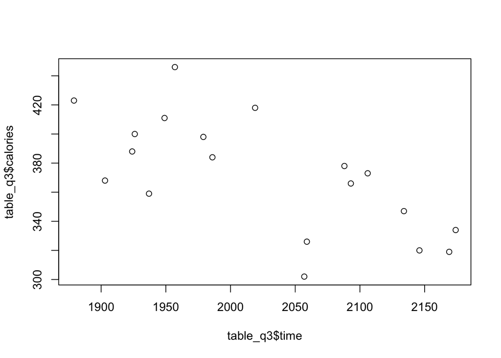

```r
#Plot the data
plot(x = table_q3$time, y = table_q3$calories)
```

```r
#Pearson's correlation
pearson<- cor.test(table_q3$time, table_q3$calories, method='pearson')
#Regression analysis
model_q3 <- lm(calories~time, data=table_q3)
summary(model_q3)
```

```
##
## Call:
## lm(formula = calories ~ time, data = table_q3)
##
## Residuals:
##    Min     1Q Median     3Q    Max
## -60.76 -15.09   4.04  15.67  55.21
##
## Coefficients:
##              Estimate Std. Error t value Pr(>|t|)
## (Intercept) 939.36422  150.70365   6.233 9.09e-06 ***
## time         -0.28031    0.07432  -3.772  0.00152 **
## ---
## Signif. codes:  0 '***' 0.001 '**' 0.01 '*' 0.05 '.' 0.1 ' ' 1
##
## Residual standard error: 30.17 on 17 degrees of freedom
## Multiple R-squared:  0.4556, Adjusted R-squared:  0.4235
## F-statistic: 14.22 on 1 and 17 DF,  p-value: 0.001522
```

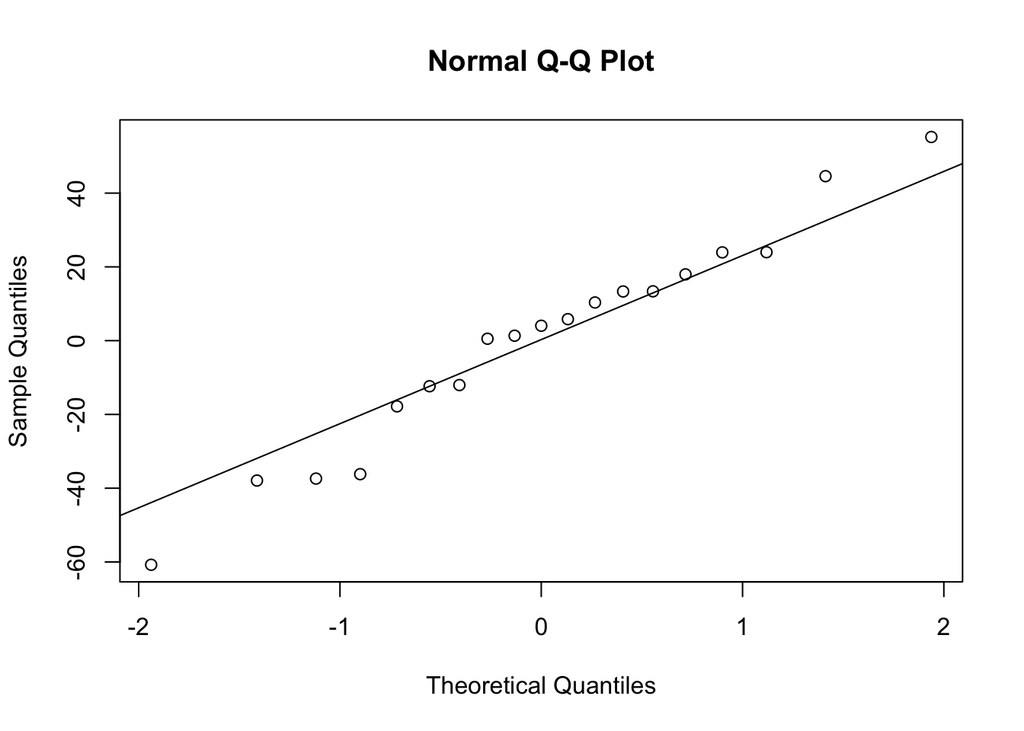

```r
#Perform diagnostics
##Use QQ-plot to find normality of residuals
qqnorm(model_q3$residuals)
qqline(model_q3$residuals)
```

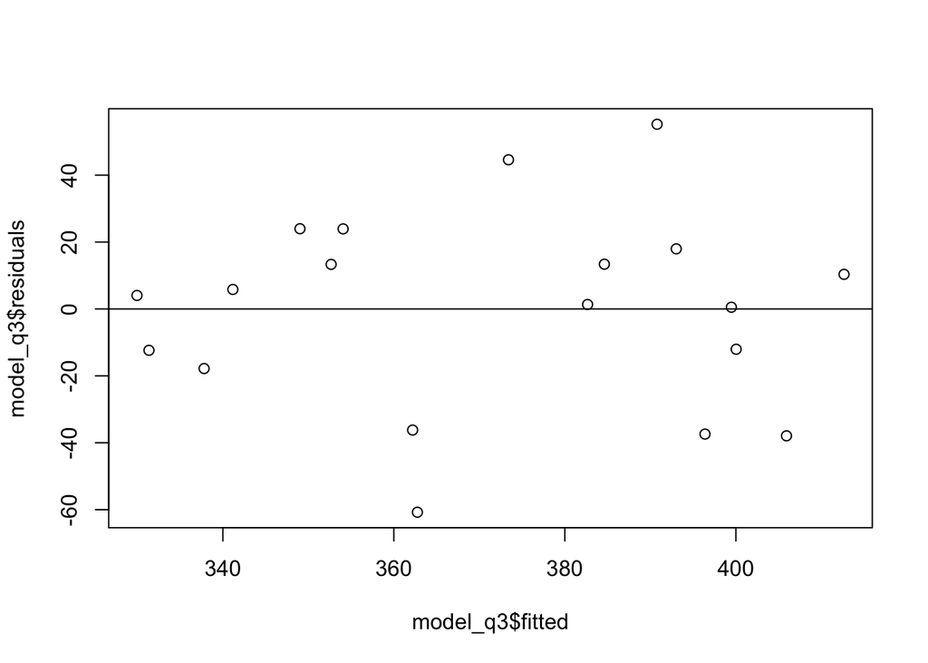

```r
##Determine if data is homoskedastic using a fitted vs. residual plot and add abline to visualise the spread
plot(y = model_q3$residuals, x = model_q3$fitted)
abline(h=0)
abline()
```

```r
###The data is normal (however not very pretty on the graph)
###The data is homoskedastic as the data points are more or less spread evenly on either side
```

*Interpretation of results:* Therefore, the p-value of the overall F-test is significant, and the regression model predicts the response variable better than the mean of the response.

# Question 4

```r
#Load packages
library(readr)
library(dplyr)
library(tidyr)

#Load fake dataset
foo <- rnorm(10000, mean = 60, sd = 3) # final mark
bar <- rnorm(10000, mean = 68, sd = 5) # project mark
baz <- rep(seq(from = 1997, to = 2006), each = 1) # years

year <- sample(baz, 150, replace = TRUE,
               prob = c(0.05, 0.05, 0.08, 0.08,
                          0.1, 0.13, 0.14, 0.13, 0.12, 0.12))
project_mark <- sample(bar, 150, replace = TRUE)
final_mark <- sample(foo, 150, replace = TRUE)

plot_data <- data_frame(year = year,
                        project_mark = round(project_mark, 1),
                        final_mark = round(final_mark, 1)) %>%
    arrange(year)


#Load data into a data frame table
table_q4 <- tbl_df(plot_data)

#Open new file device to save plot in
pdf(file='marks.pdf')

#Plot black and white, publishable figure
plot(x = project_mark, y=final_mark,
     xlab= "Project Mark (%)",
     ylab="Final Mark (%)",
     xlim=c(50,85),
     ylim=c(50,75),
     main= "The relationship between project mark and final mark",
     cex.main=1.5,
     cex=0.8,
     pch=16)

#Save and close the image
dev.off('marks.pdf')
```